# Scraping and analyzing dark net market platforms

*Nick Janetos*

*December 9th, 2015*

The 'dark net' refers to web servers which you can't find by searching on Google, either because they're not indexed, or because they hide behind some layer of security, such as the Tor network. It famously consists of new electronic marketplaces on which illicit goods are traded. For an overview, see for example two news stories on recent events.

- ["International Raids Target Sites Selling Contraband on the ‘Dark Web’", *The New York Times*, November 2014](http://www.nytimes.com/2014/11/08/world/europe/dark-market-websites-operation-onymous.html)
- ["A 50m Drug And Gun Dark Web Market Just Disappeared And Millions In Bitcoin With It", *Forbes*, March 2015](http://www.forbes.com/sites/thomasbrewster/2015/03/18/evolution-market-a-scam-says-site-pr/)

I became interested in these market platforms last year, and I noticed that there didn't seem to be much data available on the scope or inner workings of these market platforms. In September 2014 I started scraping data from the most famous of the market platforms, the Silk Road. Three months later the site was seized by the FBI and the owner arrested, by then I was scraping multiple market platforms. In the year since I've scraped a total of nine market platforms, which have variously either exited the market due to the actions of law enforcement, or disappeared along with the assets of market participants.

In this document I give a brief overview of how these markets work and how I scrape them. I show some of the data which is available, and I list some broad research questions I think are interesting.

## Scraping the dark net

All of these market platforms are accessible only through the Tor network. The Tor network is a network of servers which 'launder' web traffic, bouncing it around between themselves in order to anonymize the source of the traffic. Once an individual can access the Tor network, the marketplaces can be visited and looks similar to a marketplace like amazon.com. For example, this is what the front page of the Agora marketplace, formally one of the largest marketplaces, looked like:

[figure not shown]

I scraped these sites at (roughly) weekly intervals, then, I run the raw HTML source through scripts which extract price and listing information. The github page for the scraper is [here](https://github.com/njanetos/narchiveR). The github page for the processing scripts is [here](https://github.com/njanetos/narchiver-processor).

## General research questions

1. These marketplaces seem like a well-suited environment for empirically investigating the effects of reputation in online marketplaces, because unlike a market platform such as amazon.com, in which the buyer often has some means for recourse and the stakes are often low, here there is no means for recourse and the stakes are high (i.e., jail-time or health problems), so that reputation is more important. To my knowledge there are no compelling, tractable models of reputation suitable for empirical application, at the same time one of my research interests involves tractable models of dynamic learning. I have the first attempts at such a model of reputation [here](http://njanetos.github.io/reputation/draft.html). Related questions are:
   1. How effective are reputation mechanisms in such markets at preventing cheating?
   2. How are these market platforms affected by the closure of other market platforms (through legal action or otherwise).
2. Currently the only source of data on drug prices comes from STRIDE, which lists the prices the DEA pays for drugs which they sieze in drug busts. There is some controversy about the interpretation of these prices. How does the data from the DEA compare to the prices available on the deep web?
3. Many of these marketplaces act as intermediaries, holding funds in escrow until a deal is complete to facilitate trust. Historically, if the sum total of these escrow funds grows too large, the market platform has disappeared along with the escrow funds. Two of the market platforms instead used a 'three party authentication' system which allows the market platform to hold the funds in escrow, but 'lock' the funds until two out of the three parties involved agree to release them. Did these different trust enforcement mechanisms affect prices and success of the market platforms?

## Data description / statistics

The raw HTML is available for all of the websites, but only the Agora marketplace has the all the scripts written to fully extract the data in a machine-readable form. In this section, I describe what this data looks like.

Each market is run in roughly the same way. Sellers can post and set the price for listings. Buyers can purchase from sellers just like on amazon.com (right down to the use of a 'shopping cart'). Then, they can leave reviews once they receive the finished product. Here is a table with the first 10 listings in the dataset:

```python
from IPython.display import display
from IPython.display import HTML
import IPython.core.display as di
import numpy
import pandas
import statsmodels.api as stats
import statsmodels.formula.api as smf
import sqlite3
import os
from math import log
import matplotlib.pyplot as plt
from collections import Counter
import operator
import datetime
import matplotlib.dates as mdates

pandas.options.mode.chained_assignment = None

# Load the database
read = sqlite3.connect(os.path.join(os.getcwd(), '../combined_market/agora.db'))
read_cur = read.cursor()

read_cur.execute(""" SELECT l.title,
                            c.category,
                            v.name,
                            l.units,
                            l.amount,
                            l.quantity,
                            sf.location AS ships_from,
                            st.location AS ships_to
                            FROM listings AS l
                                JOIN categories AS c
                                    ON c.rowid == l.category
                                JOIN vendors AS v
                                    ON v.rowid == l.vendor
                                JOIN ships_from AS sf
                                    ON sf.rowid == l.ships_from
                                JOIN ships_to AS st
                                    ON st.rowid == l.ships_to""")
listings = read_cur.fetchall()

read_cur.execute(""" SELECT r.dat,
                            r.listing,
                            r.val,
                            r.content,
                            r.user_rating FROM reviews AS r""")
reviews = read_cur.fetchall()

read_cur.execute(""" SELECT p.dat,
                            p.listing,
                            p.max_sales,
                            p.min_sales,
                            p.price,
                            p.rating FROM prices AS p""")
prices = read_cur.fetchall()

# Close the connection
if read:
    read.close()

listings = pandas.DataFrame(listings, columns = ['Title', 'Category', 'Vendor', 'Units', 'Amount', 'Quantity', 'Ships from', 'Ships to'])
prices = pandas.DataFrame(prices, columns = ['Date', 'Listing id', 'Max sales', 'Min sales', 'Price', 'Rating'])
reviews = pandas.DataFrame(reviews, columns = ['Date', 'Listing id', 'Rating', 'Content', 'User rating', ])
```

```python
listings[0:10]
```

|  | Title | Category | Vendor | Units | Amount | Quantity | Ships from | Ships to |
| --- | --- | --- | --- | --- | --- | --- | --- | --- |
| 0 | Dior Logo Necklace Replica | Jewelry | foxygirl |  | 0.0 | 1 |  |  |
| 1 | Chanel Sunglasses CHL5171 Replica blackblack f... | Jewelry | Bigdeal100 |  | 0.0 | 1 |  |  |
| 2 | Ice Crystal Meth 8 OZ 224 Grams 599 OZ . Es... | Drugs.Stimulants.Meth | VerdeLimon | oz | 8.0 | 1 |  |  |
| 3 | 2.5gr. Ketamine Risomer | Drugs.Dissociatives.Ketamine | Apotheke | g | 2.5 | 1 |  |  |
| 4 | 1.0 gram Risomer KETAMINE | Drugs.Dissociatives.Ketamine | Alex-Sosa | g | 1.0 | 1 | Netherlands | WorldWideexceptUSA |
| 5 | 12 oz AlienTrain | Drugs.Cannabis.Weed | UrLocalBudTender | oz | 12.0 | 1 |  |  |
| 6 | Yohimbine Hydrochloride HCL 10g | Drugs.Weightloss | Overdos3d | g | 10.0 | 1 |  |  |
| 7 | Bayer Dbol Dianabol Methandrostenolone 10mg x ... | Drugs.Steroids | ThreeKings | mg | 10.0 | 100 | EU | Worldwide |
| 8 | MDMA 5g | Drugs.Ecstasy.MDMA | MarcelKetman | g | 5.0 | 1 |  |  |
| 9 | FE SPECIAL 20 x 30mg Adderall IR Pills TEVABAR... | Drugs.Stimulants.Prescription | FOCUSED | mg | 30.0 | 20 | USA | USA |

The columns `Title`, `Category`, `Vendor`, and `Units` are self-explanatory. The columns for `Amount` and `Quality` list the amount of the good (i.e., 30 mg) and the number of that good offered for sale in a listing. The columns `Ships from` and `Ships to` store any special information about the location the listing ships from or the location(s) it ships to.

Each listing may be scraped on multiple dates. On each date, the price of the listing is noted, as well as other seller characteristics, and the list of reviews left on that page since the last time it was scraped. These two features (price/seller characteristics and reviews) are stored separately. Here is a sample of 10 rows from the price dataset:

```python
prices[0:10]
```

|  | Date | Listing id | Max sales | Min sales | Price | Rating |
| --- | --- | --- | --- | --- | --- | --- |
| 0 | 16601 | 85835 | 5 | 3 | 14.936528 | 5 |
| 1 | 16601 | 1997 | 5 | 3 | 120.704101 | 5 |
| 2 | 16601 | 102659 | 5 | 3 | 56.328580 | 5 |
| 3 | 16601 | 109171 | 5 | 3 | 30.455572 | 5 |
| 4 | 16602 | 61915 | 5 | 3 | 0.099998 | 5 |
| 5 | 16603 | 1997 | 10 | 6 | 128.033810 | 5 |
| 6 | 16603 | 85835 | 10 | 6 | 15.843543 | 5 |
| 7 | 16603 | 102659 | 10 | 6 | 59.749112 | 5 |
| 8 | 16603 | 109171 | 10 | 6 | 32.304974 | 5 |
| 9 | 16605 | 44765 | 25 | 15 | 89.949999 | 5 |

The columns `Max sales` and `Min sales` record information the site provides on a bound for the total number of sales made by the vendor up to the date on which it was scraped. `Price` is the price of the listing at the time it was scraped (in USD), and `Rating` is the current rating of the vendor at the time the listing was scraped.

Similarly, here are the first ten rows in the dataset of reviews:

```python
reviews[0:10]
```

|  | Date | Listing id | Rating | Content | User rating |
| --- | --- | --- | --- | --- | --- |
| 0 | 16346 | 65349 | 5 | A little mess up in shipping | NaN |
| 1 | 16346 | 65349 | 5 | Totally worth it and has a damn good kick comp... | NaN |
| 2 | 16346 | 15140 | 5 | Fast shipping and good product. Stealth was go... | 5 |
| 3 | 16346 | 15140 | 5 | Great service | 5 |
| 4 | 16346 | 27732 | 5 | Very professional vendor wouldnt hesitate to ... | NaN |
| 5 | 16346 | 35159 | 5 | thanks mate arrived quickly and even an extra. | NaN |
| 6 | 16346 | 45925 | 5 | Great deal | NaN |
| 7 | 16346 | 45925 | 5 | Great deal, stealth, 4 day ship. Some high qua... | 5 |
| 8 | 16346 | 45925 | 5 | great product came 3 gs overweight... ill be back | 5 |
| 9 | 16346 | 43032 | 5 | Came in 9 days including the weekends to North... | NaN |

On this marketplace, sellers also had the opportunity to rate buyers, which is registered in the column `User rating`.

```python
# Load the data
%matplotlib notebook
from IPython.display import display
from IPython.display import HTML
import IPython.core.display as di # Example: di.display_html('<h3>%s:</h3>' % str, raw=True)
import numpy
import pandas
import statsmodels.api as stats
import statsmodels.formula.api as smf
import sqlite3
import os
from math import log
import matplotlib.pyplot as plt
from collections import Counter
import operator
import datetime
import matplotlib.dates as mdates

pandas.options.mode.chained_assignment = None

# Load the database
read = sqlite3.connect(os.path.join(os.getcwd(), 'agora.db'))
read_cur = read.cursor()

# Fetch all price information
read_cur.execute(""" SELECT p.dat AS dat,
                            l.category AS category,
                            l.vendor AS vendor,
                            p.listing AS listing,
                            p.price AS price,
                            p.rating AS rating,
                            l.amount AS amount,
                            l.quantity AS quantity,
                            l.units AS units,
                            p.reviews_per_day AS reviews_per_day,
                            p.vendor_reviews_per_day AS vendor_reviews_per_day,
                            p.dat AS normalized,
                            p.dat AS log_normalized,
                            p.rowid AS id,
                            l.ships_from,
                            l.ships_to,
                            p.dat,
                            p.vendor_net_reviews
                        FROM prices AS p
                            LEFT JOIN listings AS l
                                ON p.listing == l.rowid""")
prices = read_cur.fetchall()

# Fetch categories
read_cur.execute("""SELECT * FROM categories""")
categories = read_cur.fetchall()

# Fetch reviews
read_cur.execute("""SELECT r.dat,
                           l.category,
                           l.vendor,
                           r.listing,
                           p.price,
                           p.rating,
                           l.amount,
                           l.quantity,
                           l.units,
                           p.reviews_per_day,
                           p.vendor_reviews_per_day,
                           p.dat AS normalized,
                           p.dat AS log_normalized,
                           r.rowid AS id,
                           sf.location AS ships_from,
                           st.location AS ships_to,
                           r.val,
                           p.vendor_net_reviews
                        FROM reviews AS r
                            JOIN listings AS l
                                ON l.rowid == r.listing
                            JOIN prices AS p
                                ON p.rowid == r.matched_price
                            JOIN ships_from AS sf
                                ON sf.rowid == l.ships_from
                            JOIN ships_to AS st
                                ON st.rowid == l.ships_to""")
reviews = read_cur.fetchall()

read_cur.execute("""SELECT r.content, r.val
                        FROM reviews AS r""")
content = read_cur.fetchall()


read_cur.execute("""SELECT * FROM vendors AS v""")
vendors = read_cur.fetchall()

# Close the connection
if read:
    read.close()

# Convert tuples to lists
prices =  [ list(p) for p in prices ]
reviews = [ list(r) for r in reviews ]

# Drop impossible values
prices =  [ p for p in prices if p[6] != 0 and p[7] != 0 ]
reviews = [ r for r in reviews if r[6] != 0 and r[7] != 0 ]

# Normalize prices and try to put things in the same units
for p in prices:
    p[11] = p[4] / (p[7]*p[6])

    if "g" in p[8]:
        p[11] = p[11]/1000
        p[8] = "mg"
    elif "kg" in p[8]:
        p[11] = p[11]/1000000
        p[8] = "mg"
    elif "ug" in p[8]:
        p[11] = p[11]*1000
        p[8] = "mg"
    elif "oz" in p[8]:
        p[11] = p[11]/28349.5
        p[8] = "mg"
    elif "lb" in p[8]:
        p[11] = p[11]/453592
        p[8] = "mg"

    # Compute logs
    p[12] = log(p[11])

# Normalize reviews and try to put things in the same units
for r in reviews:
    r[11] = r[4] / (r[7]*r[6])

    if "g" in r[8]:
        r[11] = r[11]/1000
        r[8] = "mg"
    elif "kg" in r[8]:
        r[11] = r[11]/1000000
        r[8] = "mg"
    elif "ug" in r[8]:
        r[11] = r[11]*1000
        r[8] = "mg"
    elif "oz" in r[8]:
        r[11] = r[11]/28349.5
        r[8] = "mg"
    elif "lb" in r[8]:
        r[11] = r[11]/453592
        r[8] = "mg"

    # Compute logs
    r[12] = log(r[11])

# Select the stuff we normalized
prices = [ p for p in prices if 'mg' in p[8] ]
reviews = [ r for r in reviews if 'mg' in r[8] ]

# Read into panda data frame
names = ['DATE', 'CATEGORY', 'VENDOR', 'LISTING', 'PRICE',
         'RATING', 'AMOUNT', 'QUANTITY', 'UNITS', 'REVIEWS_PER_DAY',
         'V_REVIEWS_PER_DAY', 'NORMALIZED', 'LOG_NORMALIZED', 'ID',
         'SHIPS_FROM', 'SHIPS_TO', 'VAL', 'V_NET_REVIEWS']
prices = pandas.DataFrame(prices, columns = names)
reviews = pandas.DataFrame(reviews, columns = names)
content = pandas.DataFrame(content, columns = ['CONTENT', 'RATING'])
```

As can be seen in the table on reviews, most of the ratings left are '5/5's, with some '4/5's, and then another peak at '0/5'. The distribution of seller ratings, unsurprisingly, is clustered around 5.

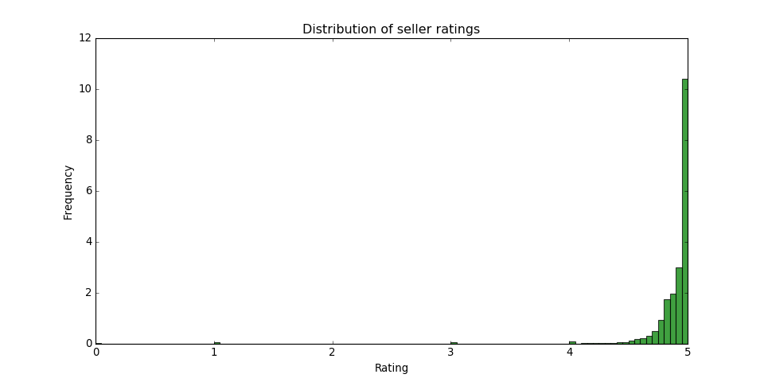

```python
fig, axes = plt.subplots(nrows = 1, ncols = 1, figsize = (12, 6))

axes.hist(reviews.loc[:,'RATING'],
                bins = 100,
                normed = True,
                facecolor = 'green',
                alpha = 0.75)
axes.set_title("Distribution of seller ratings")
axes.set_xlabel('Rating')
axes.set_ylabel('Frequency')
```

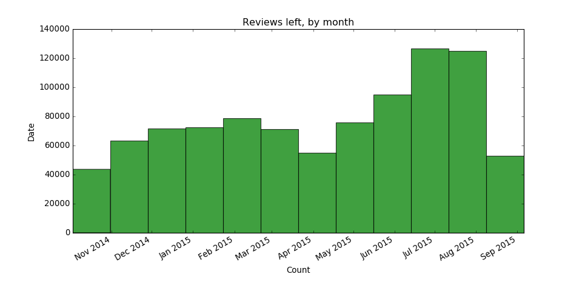

```python
fig, axes = plt.subplots(nrows = 1, ncols = 1, figsize = (12, 6))

dates = [datetime.datetime.fromtimestamp(d*86400) for d in reviews.loc[:, 'DATE']]

fig.autofmt_xdate()

axes.fmt_xdata = mdates.DateFormatter('%Y-%m-%d')

axes.hist(dates,
                bins = 12,
                normed = False,
                facecolor = 'green',
                alpha = 0.75)
axes.set_title("Reviews left, by month")
axes.set_xlabel('Count')
axes.set_ylabel('Date')
```

Usage of the Agora market surged in the months before the owners of the market decided to take it offline, citing security concerns.

I can look closely at the history of individual sellers in the market. For example, here are plots of the reviews left, an estimate of average daily reviews, and the ratings path for a single vendor.

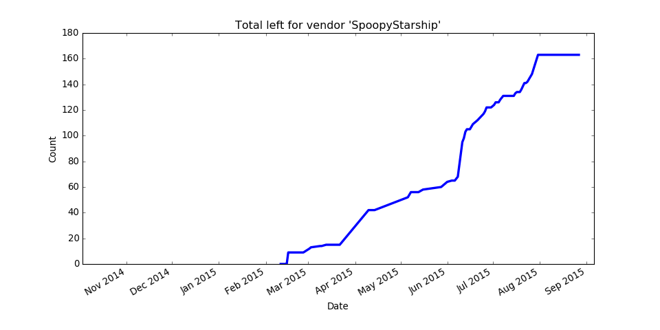

```python
fig, axes = plt.subplots(nrows = 1, ncols = 1, figsize = (12, 6))

reviews_vendor = prices[prices['VENDOR'] == 5]

dates_new = [datetime.datetime.fromtimestamp(d*86400) for d in reviews_vendor.loc[:, 'DATE']]

fig.autofmt_xdate()

axes.fmt_xdata = mdates.DateFormatter('%Y-%m-%d')

axes.plot(dates_new, reviews_vendor['V_NET_REVIEWS'], linewidth = 3)
axes.set_title("Total left for vendor 'SpoopyStarship'")
axes.set_xlabel('Date')
axes.set_xlim(min(dates), max(dates))
axes.set_ylabel('Count')
```

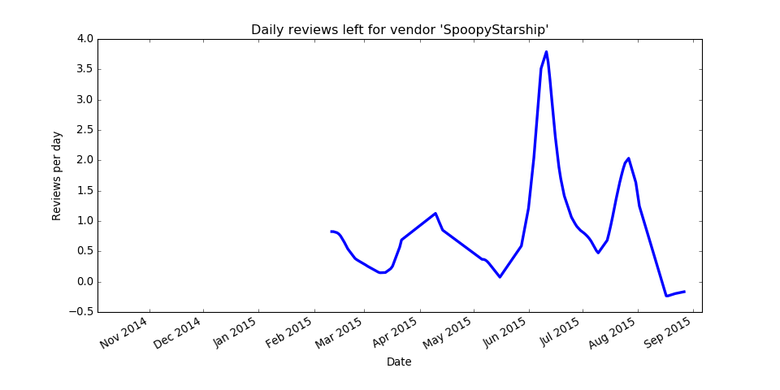

```python
fig, axes = plt.subplots(nrows = 1, ncols = 1, figsize = (12, 6))

reviews_vendor = prices[prices['VENDOR'] == 5]

dates_new = [datetime.datetime.fromtimestamp(d*86400) for d in reviews_vendor.loc[:, 'DATE']]

fig.autofmt_xdate()

axes.fmt_xdata = mdates.DateFormatter('%Y-%m-%d')

axes.plot(dates_new, reviews_vendor['V_REVIEWS_PER_DAY'], linewidth = 3)
axes.set_title("Daily reviews left for vendor 'SpoopyStarship'")
axes.set_xlabel('Date')
axes.set_xlim(min(dates), max(dates))
axes.set_ylabel('Reviews per day')
```

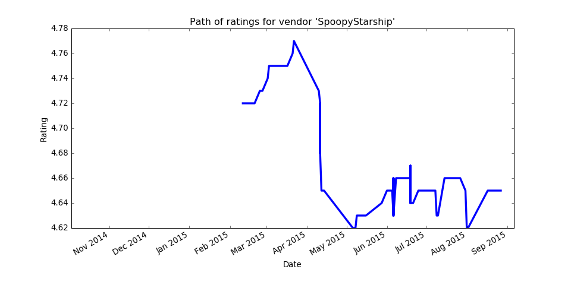

```python
fig, axes = plt.subplots(nrows = 1, ncols = 1, figsize = (12, 6))

reviews_vendor = prices[prices['VENDOR'] == 5]

dates_new = [datetime.datetime.fromtimestamp(d*86400) for d in reviews_vendor.loc[:, 'DATE']]

fig.autofmt_xdate()

axes.fmt_xdata = mdates.DateFormatter('%Y-%m-%d')

axes.plot(dates_new, reviews_vendor['RATING'], linewidth = 3)
axes.set_title("Path of ratings for vendor 'SpoopyStarship'")
axes.set_xlabel('Date')
axes.set_xlim(min(dates), max(dates))
axes.set_ylabel('Rating')
```

```python
# Hide stuff
from IPython.display import HTML
import warnings

warnings.filterwarnings('ignore')
HTML('''<script>$('div.input').hide();</script>''')
```